# ANALYSE D'AUDIENCE ET DES REACTIONS POUR UN PROGRAMME TELE : CAS DE *SQUID GAME*

[figure not shown]

Réalisé par :

- Alexandra **ANVOH**
- Jean-Baptiste **KOFFI**
- Prosper **KOUASSI**

## Introduction et contexte

Dans le cadre de ce projet, nous nous intéressons à l’analyse de l’audience et des réactions autour d’un programme télévisé. Avec l’essor des plateformes de streaming et des réseaux sociaux, les séries sont aujourd’hui massivement commentées en ligne, générant une quantité importante de données textuelles. Ces avis, notes et commentaires constituent une source d’information précieuse pour comprendre la perception du public, identifier les thèmes qui émergent naturellement et mesurer l’intensité des réactions.

L’objectif de ce travail est d’appliquer des méthodes de Traitement Automatique du Langage Naturel (TALN) afin d’extraire automatiquement des connaissances à partir de commentaires d’internautes portant sur la série **Squid Game**.

Squid Game est une série sud-coréenne diffusée sur Netflix, devenue un phénomène mondial dès sa sortie en 2021. Elle met en scène des centaines de candidats endettés qui participent à des jeux inspirés de ceux de l’enfance, mais dont l’issue est mortelle. Mélangeant thriller, drame social et critique du système économique, la série explore des thèmes tels que l’inégalité, la survie, la moralité et la valeur de la vie humaine. Son succès massif a généré un volume considérable de discussions, d’avis et de réactions en ligne, constituant un terrain riche pour l’analyse d’audience et le traitement automatique du langage naturel.

À partir d’un ensemble de données composé de notes attribuées par les utilisateurs et de textes d’avis extraits sur le site **AlloCiné**, nous cherchons à analyser le sentiment global, détecter les thèmes dominants et observer les tendances d’opinions. Pour cela, nous mobilisons plusieurs techniques de prétraitement, d’analyse linguistique, ainsi que des méthodes plus avancées telles que l’analyse de sentiments ou la modélisation thématique. Ce travail permet non seulement de mettre en œuvre des outils modernes du NLP, mais aussi de mieux comprendre les dynamiques d’audience autour d’un contenu audiovisuel.

**Source des données :** https://www.allocine.fr/series/ficheserie-29898/critiques/

## Exploration approfondie des données

- **Description des données**

```python
# importation de la bibliothèque pandas pour le chargement des données
import pandas as pd
df = pd.read_csv("allocine_squidgame_reviews.csv", decimal=",")

# affichage des 5 premières lignes
df.head()
```

|  | author | rating | title | content |
| --- | --- | --- | --- | --- |
| 0 | NaN | 1.5 | NaN | Répétition en boucle: les votes ,les jeux et e... |
| 1 | NaN | 3.5 | NaN | Une saison en demi teinte. Un début très lourd... |
| 2 | NaN | 0.5 | NaN | Une saison nullissime qui n'a plus que son nom... |
| 3 | NaN | 2.5 | NaN | Je ne comprends comment après avoir tracé si f... |
| 4 | NaN | 0.5 | NaN | Scénario écrit avec les pieds. On se fait pren... |

```python
# affichage des dimmensions du jeu de données
print('la dimension est',df.shape)
```

```
la dimension est (918, 4)
```

Le jeu de données originel est constitué de **918 lignes** et **4 colonnes**. Les colonnes **'author'** et **'title'** relatifs à l'auteur et au titre du commentaire ne contiennent pas de valeurs. On va donc les retirer pour ne garder que les colonnes **'rating'** et **'content'** qui vont nous servir pour le travail. Ces colonnes contiennent les notes attribués et les commentaires. Donc le nouveau jeu de données va être constitué de **918 lignes** et **2 colonnes**.

```python
df=df[['rating', 'content']]

df.head()
```

|  | rating | content |
| --- | --- | --- |
| 0 | 1.5 | Répétition en boucle: les votes ,les jeux et e... |
| 1 | 3.5 | Une saison en demi teinte. Un début très lourd... |
| 2 | 0.5 | Une saison nullissime qui n'a plus que son nom... |
| 3 | 2.5 | Je ne comprends comment après avoir tracé si f... |
| 4 | 0.5 | Scénario écrit avec les pieds. On se fait pren... |

On cherche à présent à obtenir des informations sur les colonnes elles-mêmes, sur leurs types notamment, grâce à df.info ()

```python
df.info()
```

```
<class 'pandas.core.frame.DataFrame'>
RangeIndex: 918 entries, 0 to 917
Data columns (total 2 columns):
 #   Column   Non-Null Count  Dtype
---  ------   --------------  -----
 0   rating   918 non-null    float64
 1   content  918 non-null    object
dtypes: float64(1), object(1)
memory usage: 14.5+ KB
```

La colonne **'rating'** contient des données de type *float* et la colonne **'content'**, des données de type *object*.

Voyons à présent si les données contiennent des valeurs manquantes.

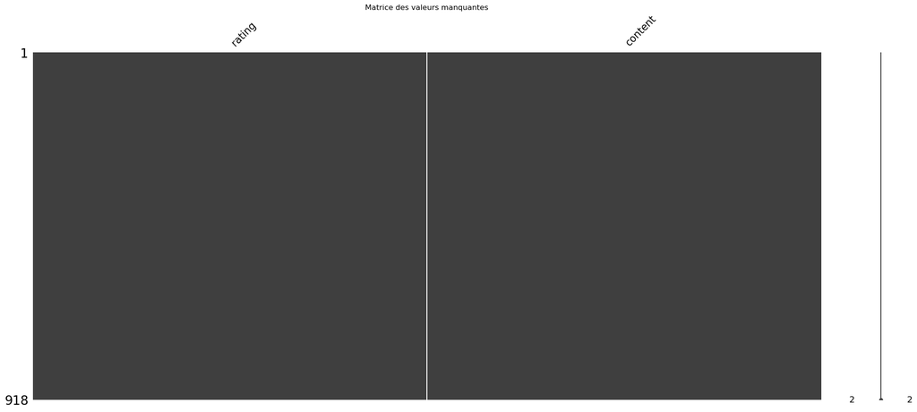

```python
import missingno as msno
import matplotlib.pyplot as plt

msno.matrix(df)
plt.title('Matrice des valeurs manquantes')
plt.show()
```

La bibliothèque **missingno** combinée à la bibliothèque **matplotlib** permettent de représenter les données sous forme de barre, une barre pour chaque variable. Lorsqu'une variable présente des valeurs manquantes, on observe des rayures dans la colonne correspondante.

Le graphique ne montre aucune rayure dans les colonnes **rating** et **content**. Il n'y a donc pas de valeurs manquantes.

- **Préparation des données**

On commence par afficher les différentes valeurs prises par la variable **'rating'**. Ces valeurs vont nous servir à construire une variable **'feeling'** qui prendra les valeurs *positif* ou *négatif* en fonction de la valeur de **'rating'**.

```python
df['rating'].unique()
```

```
array([1.5, 3.5, 0.5, 2.5, 3. , 4. , 2. , 5. , 4.5, 1. ])
```

On peut également regarder de plus près la rapartition des données en fonction du **rating**.

```python
df['rating'].value_counts()
```

```
rating
5.0    180
4.0    165
3.5    108
4.5     92
0.5     81
3.0     76
2.0     66
1.0     60
2.5     55
1.5     35
Name: count, dtype: int64
```

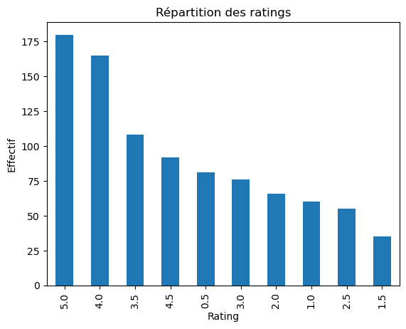

```python
df['rating'].value_counts().plot(kind='bar')
plt.title('Répartition des ratings')
plt.xlabel('Rating')
plt.ylabel('Effectif')
plt.show()
```

On applique cette labélisation aux données.

```python
import numpy as np

df['feeling'] = np.where(df['rating'] >= 3.5, 'positif', 'negatif')

df.head()
```

|  | rating | content | feeling |
| --- | --- | --- | --- |
| 0 | 1.5 | Répétition en boucle: les votes ,les jeux et e... | negatif |
| 1 | 3.5 | Une saison en demi teinte. Un début très lourd... | positif |
| 2 | 0.5 | Une saison nullissime qui n'a plus que son nom... | negatif |
| 3 | 2.5 | Je ne comprends comment après avoir tracé si f... | negatif |
| 4 | 0.5 | Scénario écrit avec les pieds. On se fait pren... | negatif |

- Analyse visuelle

Il peut être intéressant de voir de plus près les mots qui reviennent le plus dans le corpus de commentaires. Pour cela nous allons construire un nuage de mots. Mais, avant cela, une étape préalable de nettotage de la colonne **content** (contenant les commentaires) est faite en se basant sur les *stopwords*.

```python
import nltk
from nltk.corpus import stopwords
import re
```

```python
# Fonction de nettoyage de la colonne 'content' en français
stop_words_fr = set(stopwords.words("french"))

def nettoyage_content(content):
    if not isinstance(content, str):
        return ""

    # Retrait des URL
    content = re.sub(r"https?://\S+|www\.\S+", " ", content)
    # Retrait du HTML éventuel
    content = re.sub(r"<.*?>|&([a-z0-9]+|#[0-9]{1,6}|#x[0-9a-f]{1,6});", " ", content)
    # Retrait de la ponctuation (conserve les apostrophes pour le français)
    content = re.sub(r"[^\w\s']", " ", content)
    # Retrait des mots avec nombres (comme 'AJA89')
    content = re.sub(r"\w*\d\w*", " ", content)
    # Retrait des valeurs numériques
    content = re.sub(r"[0-9]+", " ", content)
    # Retrait des espaces multiples
    content = re.sub(r"\s+", " ", content).strip()
    # Tout en minuscule
    content = content.lower()

    # Tokenization et retrait des stopwords français
    tokens = []
    for token in content.split():
        if token not in stop_words_fr and len(token) > 2:  # filtre les mots trop courts
            tokens.append(token)

    return " ".join(tokens)

# Application sur la colonne content
df.loc[:, "content"] = df["content"].apply(nettoyage_content)
df.head()
```

|  | rating | content | feeling |
| --- | --- | --- | --- |
| 0 | 1.5 | répétition boucle votes jeux entre temps longu... | negatif |
| 1 | 3.5 | saison demi teinte début très lourd long redém... | positif |
| 2 | 0.5 | saison nullissime n'a plus nom convaincre ceux... | negatif |
| 3 | 2.5 | comprends comment après avoir tracé finement c... | negatif |
| 4 | 0.5 | scénario écrit pieds fait prendre idiots scéna... | negatif |

On obtient le nuage de mots ci-dessous :

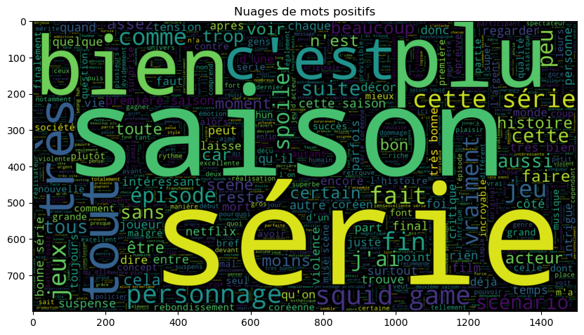

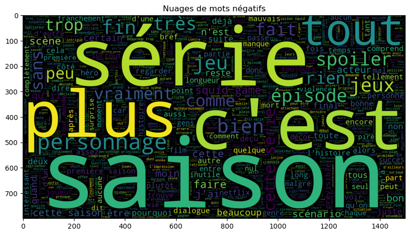

```python
from wordcloud import WordCloud

plt.figure(figsize=(10,10))
wc = WordCloud(max_words=5000, width=1500, height=800).generate(" ".join(df[df.feeling == 'positif'].content))
plt.title("Nuages de mots positifs")
plt.imshow(wc, interpolation='bilinear')


plt.figure(figsize=(10,10))
wc = WordCloud(max_words=5000, width=1500, height=800).generate(" ".join(df[df.feeling == 'negatif'].content))
plt.title("Nuages de mots négatifs")
plt.imshow(wc, interpolation='bilinear')
```

On accompagne ce nuage de mots d'un diagramme relatif aux impressions des commentateurs.

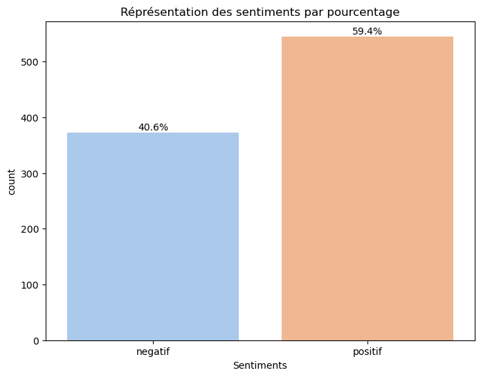

```python
import seaborn as sns
import matplotlib.pyplot as plt

plt.figure(figsize=(8, 6))
ax = sns.countplot(x=df['feeling'], data=df, palette='pastel')
plt.title('Réprésentation des sentiments par pourcentage')
plt.xlabel('Sentiments')

# Ajouter les pourcentages sur les barres
total = len(df['feeling'])
for p in ax.patches:
    percentage = f'{100 * p.get_height() / total:.1f}%'
    x = p.get_x() + p.get_width() / 2
    y = p.get_height() + 0.05
    ax.annotate(percentage, (x, y), ha='center', va='bottom')

plt.show()
```

Ces nuages de mots et ce diagramme nous donnent un aperçu rapide et intuitif des termes les plus importants ou fréquents dans ce jeu de données ainsi que le sentiment général.

On peut toutefois regarder de plus près quel est l'avis réel des internautes vis à vis de cette série au travers d'une analyse beaucoup plus approfondie.

On s'intéresse ici aux adjectifs et verbes qui peuvent être beacoup plus parlants par rapport aux mots pris dans leur globalité.

- Etiquetage des commentaires, récupération du résultat pour construire un nuage de mots pour les verbes et adjectifs

```python
import spacy
nlp = spacy.load("fr_core_news_md")
```

```python
def get_pos_tokens(text):
    doc = nlp(text)
    return [(token.text, token.pos_) for token in doc]


df['pos_tags'] = df['content'].apply(get_pos_tokens)
df[['content', 'pos_tags']].head()
```

|  | content | pos_tags |
| --- | --- | --- |
| 0 | répétition boucle votes jeux entre temps longu... | [(répétition, NOUN), (boucle, NOUN), (votes, N... |
| 1 | saison demi teinte début très lourd long redém... | [(saison, NOUN), (demi, ADJ), (teinte, NOUN), ... |
| 2 | saison nullissime n'a plus nom convaincre ceux... | [(saison, NOUN), (nullissime, VERB), (n', ADV)... |
| 3 | comprends comment après avoir tracé finement c... | [(comprends, VERB), (comment, ADV), (après, AD... |
| 4 | scénario écrit pieds fait prendre idiots scéna... | [(scénario, NOUN), (écrit, VERB), (pieds, NOUN... |

```python
# extraire les verbes
def extract_verbs(text):
    doc = nlp(text)
    verbs = [token.lemma_ for token in doc if token.pos_ == 'VERB']
    return verbs


# extraire les adjectifs
def extract_adj(text):
    doc = nlp(text)
    adj = [token.lemma_ for token in doc if token.pos_ == 'ADJ']
    return adj


df['verbs'] = df['content'].apply(extract_verbs)
df['adj'] = df['content'].apply(extract_adj)
```

```python
import itertools

verbs = list(itertools.chain.from_iterable(df['verbs']))
adj = list(itertools.chain.from_iterable(df['adj']))
```

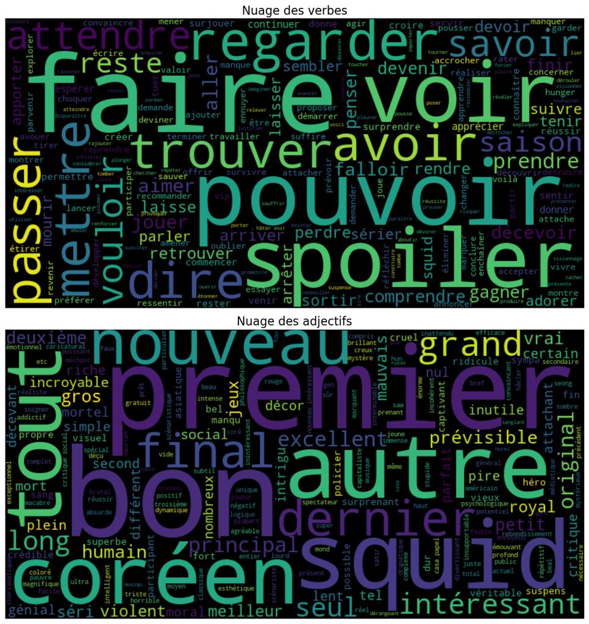

```python
from wordcloud import WordCloud
import matplotlib.pyplot as plt

# Création des textes
verbs_text = " ".join(verbs)
adj_text = " ".join(adj)

# Génération des wordclouds
wc_verbs = WordCloud(width=800, height=400, background_color='black').generate(verbs_text)
wc_adj = WordCloud(width=800, height=400, background_color='black').generate(adj_text)

# Affichage en vertical
plt.figure(figsize=(12, 12))

# Nuage des verbes
plt.subplot(2, 1, 1)
plt.imshow(wc_verbs, interpolation='bilinear')
plt.title("Nuage des verbes", fontsize=16)
plt.axis('off')
plt.imshow(wc_verbs, interpolation='bilinear')

# Nuage des adjectifs
plt.subplot(2, 1, 2)
plt.imshow(wc_adj, interpolation='bilinear')
plt.title("Nuage des adjectifs", fontsize=16)
plt.axis('off')
plt.imshow(wc_adj, interpolation='bilinear')

plt.tight_layout()
#plt.show()
```

Le nuage de mots relatif aux adjectifs montre que les commentaires du public sont globalement positifs, avec une grande fréquence de termes valorisants comme **bon**, **excellent**, **intéressant**, **original**, etc. Cependant, la présence visible de termes négatifs tels que **décevant**, **violent**, **lent** ou **inutile** indique que la série génère aussi des réactions critiques.

### **Conclusion partielle**

En résumé, l’audience perçoit la série comme un contenu original, marquant et souvent de très bonne qualité, mais certains spectateurs restent critiques sur le rythme, la violence ou la cohérence narrative.

Ce résultat confirme que Squid Game est une œuvre fortement engageante, suscitant autant d’adhésion que de débats, ce qui se reflète dans la polarisation lexicale présente dans les commentaires.

Toutefois, connaître l’avis global ne suffit pas lorsqu’on souhaite traiter des milliers de commentaires en temps réel. L’entraînement d’un modèle permet d’automatiser cette analyse à grande échelle, de gagner du temps, et de rendre possible une surveillance continue des réactions du public. Ainsi, la construction du modèle répond à un besoin d’efficacité et de scalabilité.

# Construction et Entrainement de modèles

```python
from sklearn.model_selection import train_test_split
from sklearn.feature_extraction.text import TfidfVectorizer
from sklearn.naive_bayes import MultinomialNB
from sklearn.metrics import accuracy_score, classification_report, confusion_matrix
from nltk.tokenize import word_tokenize
from sklearn.ensemble import RandomForestClassifier

import torch
import numpy as np
from transformers import BertTokenizer, BertForSequenceClassification
from torch.optim import AdamW
from torch.utils.data import DataLoader, TensorDataset
```

### **Modèle multinomialNB**

```python
# Séparation des données en ensembles d'entraînement et de test
X_train, X_test, y_train, y_test = train_test_split(df['content'], df['feeling'], test_size=0.2, random_state=42)
# Vectorisation TF-IDF
vectorizer = TfidfVectorizer()
X_train_tfidf = vectorizer.fit_transform(X_train)
X_test_tfidf = vectorizer.transform(X_test)
```

```
Accuracy MultinomialNB: 71.74%
```

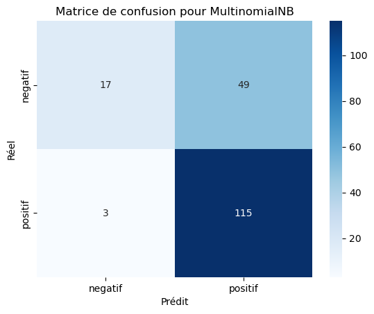

```python
# Modèle Multinomial Naive Bayes
model_nb = MultinomialNB()
model_nb.fit(X_train_tfidf, y_train)
# Prédictions
y_pred_nb = model_nb.predict(X_test_tfidf)
# EVALUATION DU MODELE MultinomialNB

accuracy_1 = accuracy_score(y_test, y_pred_nb) * 100
print("Accuracy MultinomialNB: {:.2f}%".format(accuracy_1))
# matrice de confusion
import seaborn as sns
import matplotlib.pyplot as plt
cm_1 = confusion_matrix(y_test, y_pred_nb)
sns.heatmap(cm_1, annot=True, fmt='d', cmap='Blues', xticklabels=['negatif', 'positif'], yticklabels=['negatif', 'positif'])
plt.xlabel('Prédit')
plt.ylabel('Réel')
plt.title('Matrice de confusion pour MultinomialNB')
plt.show()
```

- Utilisation de **multinomialNB** pour d'autres commentaires

```python
def analyser_sentiment():
    commentaire = input("💬 Entrez votre commentaire: ")

    # Vectorisation et netoyage
    commentaire_nettoye = nettoyage_content(commentaire)

    print(f" Commentaire nettoyé: '{commentaire_nettoye}'")
    commentaire_vec = vectorizer.transform([commentaire_nettoye])

    # Prédiction avec le modèle ( MultinomialNB)
    prediction_texte = model_nb.predict(commentaire_vec)[0]

    probas = model_nb.predict_proba(commentaire_vec)[0]

    print(f"\n RÉSULTAT POUR: '{commentaire}'")

    print("=" * 50)
    print(f" SENTIMENT PRÉDIT EST: {prediction_texte.upper()}")
    print(f"AVEC UNE PROBABILITE DE: {max(probas)*100:.1f}%")




# Test
analyser_sentiment()
```

```
 Commentaire nettoyé: 'squid game imposée comme survival game plus marquant dernières années porté concept original univers devenu culte série captive intensité rebondissements personnages marquants réussi marquer esprits suspense rebondissements intensité jeux rendent expérience totalement addictiv…

 RÉSULTAT POUR: 'Squid Game" s’est imposée comme le survival game le plus marquant de ces dernières années. Porté par un concept original et un univers devenu culte, la série captive par son intensité, ses rebondissements et ses personnages marquants. Elle a réussi à marquer les esprits avec son sus…
==================================================
 SENTIMENT PRÉDIT EST: POSITIF
AVEC UNE PROBABILITE DE: 91.8%
```

### **Modèle BERT**

```python
# Tokenisation
tokenizer = BertTokenizer.from_pretrained('bert-base-uncased')

def tokenize_function(texts):
    return tokenizer(
        texts.tolist(),
        padding=True,
        truncation=True,
        max_length=128,
        return_tensors="pt"
    )

# Tokeniser tous les commentaires
encodings = tokenize_function(df['content'])

# S'assurer que les labels sont numériques
df['label'] = df['feeling'].map({'positif': 1, 'negatif': 0})

# Solution simple - split direct des tensors
train_size = int(0.8 * len(df))
val_size = len(df) - train_size

# Créer les datasets
train_dataset = TensorDataset(
    encodings['input_ids'][:train_size],
    encodings['attention_mask'][:train_size],
    torch.tensor(df['label'].values[:train_size], dtype=torch.long)
)

val_dataset = TensorDataset(
    encodings['input_ids'][train_size:],
    encodings['attention_mask'][train_size:],
    torch.tensor(df['label'].values[train_size:], dtype=torch.long)
)

# Créer les DataLoaders
train_loader = DataLoader(train_dataset, batch_size=16, shuffle=True)
val_loader = DataLoader(val_dataset, batch_size=16, shuffle=False)



# Charger le modèle BERT
model_BERT = BertForSequenceClassification.from_pretrained(
    'bert-base-uncased',
    num_labels=2
)

# Configuration de l'entraînement - CORRECTION ICI
optimizer = AdamW(model_BERT.parameters(), lr=2e-5)

# Entraînement
model_BERT.train()
for epoch in range(3):
    total_loss = 0
    for batch in train_loader:
        input_ids, attention_mask, labels = batch

        optimizer.zero_grad()

        outputs = model_BERT(
            input_ids=input_ids,
            attention_mask=attention_mask,
            labels=labels
        )

        loss = outputs.loss
        total_loss += loss.item()

        loss.backward()
        optimizer.step()

    print(f"Epoch {epoch+1}, Loss: {total_loss/len(train_loader):.4f}")

# Évaluation
model_BERT.eval()
all_predictions = []
all_labels = []

with torch.no_grad():
    for batch in val_loader:
        input_ids, attention_mask, labels = batch

        outputs = model_BERT(
            input_ids=input_ids,
            attention_mask=attention_mask
        )

        predictions = torch.argmax(outputs.logits, dim=1)
        all_predictions.extend(predictions.cpu().numpy())
        all_labels.extend(labels.cpu().numpy())
```

[output not shown]

[output not shown]

[output not shown]

```
Some weights of BertForSequenceClassification were not initialized from the model checkpoint at bert-base-uncased and are newly initialized: ['classifier.bias', 'classifier.weight']
You should probably TRAIN this model on a down-stream task to be able to use it for predictions and inference.
```

```
Epoch 1, Loss: 0.6764
Epoch 2, Loss: 0.6381
Epoch 3, Loss: 0.5433
```

- Les métriques

```
Accuracy BERT: 67.39%
```

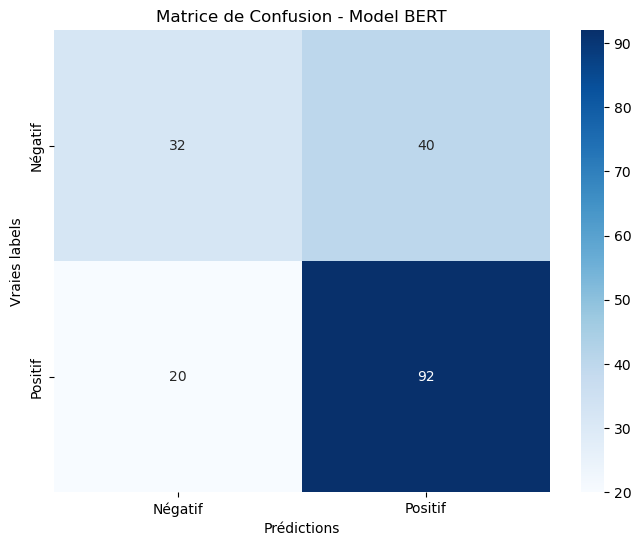

```python
import matplotlib.pyplot as plt
import seaborn as sns
import numpy as np

# Calcul de l'accuracy
accuracy = accuracy_score(all_labels, all_predictions)*100

print("Accuracy BERT: {:.2f}%".format(accuracy))


# Affichage détaillé de la matrice de confusion
plt.figure(figsize=(8, 6))
cm = confusion_matrix(all_labels, all_predictions)
sns.heatmap(cm, annot=True, fmt='d', cmap='Blues',
            xticklabels=['Négatif', 'Positif'],
            yticklabels=['Négatif', 'Positif'])
plt.xlabel('Prédictions')
plt.ylabel('Vraies labels')
plt.title('Matrice de Confusion - Model BERT')
plt.show()
```

- Utilisation de **BERT** pour d'autres commentaires

```python
def analyser_sentiment_BERT():
    commentaire = input("💬 Entrez votre commentaire: ")

    # Tokenisation
    inputs = tokenizer(
        commentaire,
        padding=True,
        truncation=True,
        max_length=128,
        return_tensors="pt"
    )

    # Prédiction
    model_BERT.eval()
    with torch.no_grad():
        outputs = model_BERT(**inputs)
        predictions = torch.argmax(outputs.logits, dim=1)
        probas = torch.softmax(outputs.logits, dim=1)

    sentiment = "positif" if predictions[0] == 1 else "negatif"
    confidence = probas[0][predictions[0]].item() * 100
    print(f"\n RÉSULTAT POUR: '{commentaire}'")
    print("=" * 50)
    print(f"\nRÉSULTAT DE SENTIMENT: {sentiment.upper()}")
    print(f"AVEC UNE PROBABILITE DE : {confidence:.1f}%")

# Test
analyser_sentiment_BERT()
```

```
 RÉSULTAT POUR: 'je n'ai pas du tout apprécié cette série'
==================================================

RÉSULTAT DE SENTIMENT: NEGATIF
AVEC UNE PROBABILITE DE : 58.3%
```

## Autres Modèles

### **Modèle RandomForestClassifie**

```
Accuracy Randomforestclassifier: 79.89%
```

[figure not shown]

```python
model_Rand = RandomForestClassifier(n_estimators=100, random_state=42)
model_Rand.fit(X_train_tfidf, y_train)
# Prédictions
y_pred_Rand = model_Rand.predict(X_test_tfidf)


# EVALUATION DU MODELE MultinomialNB

accuracy_rand = accuracy_score(y_test, y_pred_Rand) * 100
print("Accuracy Randomforestclassifier: {:.2f}%".format(accuracy_rand))
# matrice de confusion
import seaborn as sns
import matplotlib.pyplot as plt
cm = confusion_matrix(y_test, y_pred_Rand)
sns.heatmap(cm, annot=True, fmt='d', cmap='Blues', xticklabels=['negatif', 'positif'], yticklabels=['negatif', 'positif'])
plt.xlabel('Prédit')
plt.ylabel('Réel')
plt.title('Matrice de confusion pour MultinomialNB')
plt.show()
```

### **Modèle XGBClassifie**

[output not shown]

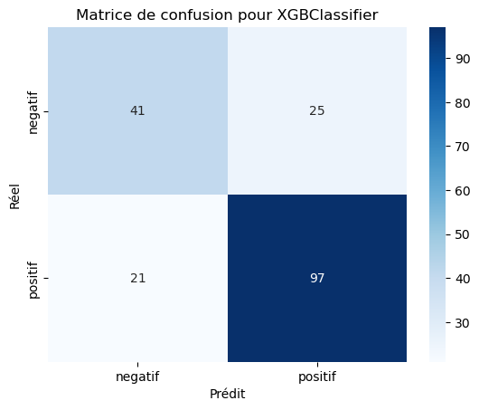

```python
from sklearn.preprocessing import LabelEncoder

# Convertir les labels textuels en numériques
label_encoder = LabelEncoder()
y_train_encoded = label_encoder.fit_transform(y_train)
y_test_encoded = label_encoder.transform(y_test)

# Maintenant entraîner XGBoost
from xgboost import XGBClassifier
modele_3 = XGBClassifier(
    n_estimators=100,
    learning_rate=0.1,
    max_depth=3,
    random_state=42
)
modele_3.fit(X_train_tfidf, y_train_encoded)
y_pred_3_encoded = modele_3.predict(X_test_tfidf)

# Reconvertir en texte pour l'évaluation
y_pred_3 = label_encoder.inverse_transform(y_pred_3_encoded)

# evaluation
accuracy_3 = accuracy_score(y_test, y_pred_3) * 100
print("Accuracy Randomforestclassifier: {:.2f}%".format(accuracy_3))
# matrice de confusion
import seaborn as sns
import matplotlib.pyplot as plt
cm = confusion_matrix(y_test, y_pred_3)
sns.heatmap(cm, annot=True, fmt='d', cmap='Blues', xticklabels=['negatif', 'positif'], yticklabels=['negatif', 'positif'])
plt.xlabel('Prédit')
plt.ylabel('Réel')
plt.title('Matrice de confusion pour XGBClassifier')
plt.show()
```

### **Modèle GradientBoostingClassifier**

[output not shown]

[figure not shown]

```python
from sklearn.ensemble import GradientBoostingClassifier


# Initialisation du modèle
modele_gb = GradientBoostingClassifier(
    n_estimators=100,
    learning_rate=0.1,
    max_depth=3,
    random_state=42
)

# Entraînement (sans besoin de conversion des labels)
modele_gb.fit(X_train_tfidf, y_train)

# Prédiction
y_pred_gb = modele_gb.predict(X_test_tfidf)

# evaluation
accuracy_= accuracy_score(y_test, y_pred_gb) * 100
print("Accuracy Randomforestclassifier: {:.2f}%".format(accuracy_))
# matrice de confusion
import seaborn as sns
import matplotlib.pyplot as plt
cm = confusion_matrix(y_test, y_pred_gb)
sns.heatmap(cm, annot=True, fmt='d', cmap='Blues', xticklabels=['negatif', 'positif'], yticklabels=['negatif', 'positif'])
plt.xlabel('Prédit')
plt.ylabel('Réel')
plt.title('Matrice de confusion pour XGBClassifier')
plt.show()
```

### Utilisation pour la prédiction

De ces trois modèles, on retient **RandomForestClassifie** car il a une bonne performance (**79.89%**), et les **faux positifs** sont au nombre de **23** contre (**25** et **28**) pour les deux autres.

```python
def analyser_sentiment_rand():
    commentaire = input("💬 Entrez votre commentaire: ")

    # Vectorisation et netoyage
    commentaire_nettoye = nettoyage_content(commentaire)

    print(f" Commentaire nettoyé: '{commentaire_nettoye}'")
    commentaire_vec = vectorizer.transform([commentaire_nettoye])

    # Prédiction avec le modèle ( MultinomialNB)
    prediction_texte = model_Rand.predict(commentaire_vec)[0]

    probas = model_Rand.predict_proba(commentaire_vec)[0]

    print(f"\n RÉSULTAT POUR: '{commentaire}'")

    print("=" * 50)
    print(f" SENTIMENT PRÉDIT EST: {prediction_texte.upper()}")
    print(f"AVEC UNE PROBABILITE DE: {max(probas)*100:.1f}%")




# Test
analyser_sentiment_rand()
```

```
 Commentaire nettoyé: 'interessé cette série'

 RÉSULTAT POUR: 'je suis interessé par cette série'
==================================================
 SENTIMENT PRÉDIT EST: POSITIF
AVEC UNE PROBABILITE DE: 89.0%
```

## Conclusion

L’analyse menée sur l’ensemble des commentaires a d’abord permis de dégager une tendance générale claire : les spectateurs expriment majoritairement un avis globalement cohérent, révélant les principaux points d’appréciation ou de critique à propos du programme étudié. Toutefois, si cette vision d’ensemble apporte une première lecture utile, elle reste limitée pour comprendre la diversité des ressentis exprimés individuellement dans les commentaires.

C’est précisément pour dépasser cette limite que nous avons construit et entraîné plusieurs modèles de classification automatique. Ces modèles ont montré des performances globalement satisfaisantes, capables non seulement d’identifier le sentiment associé à chaque commentaire, mais surtout de généraliser à de nouveaux textes en capturant des nuances que des statistiques globales ne peuvent pas refléter.

Ainsi, l’intégration de ces modèles d’apprentissage automatique enrichit l’analyse en offrant une lecture fine, scalable et objective du ressenti des utilisateurs. En combinant la vision globale et la classification automatique, notre étude permet non seulement de confirmer les tendances dominantes, mais aussi d’automatiser l’évaluation future de nouveaux commentaires, rendant l’approche particulièrement pertinente pour un usage opérationnel continu.